# Introduction to Machine Learning in R

Evan Muzzall and Chris Kennedy

3/07/2018

# Introduction

Be sure to check out the D-Lab [Machine Learning Working Group](http://dlab.berkeley.edu/working-groups/machine-learning-working-group-0) to learn more about machine learning in both R and Python, give a lightning talk, lead a coding walkthrough, and participate in other projects.

### 1. Package installation

```r
if (FALSE) {
  # Run this line manually to install the necessary packages.
  install.packages(c("car", "caret","chemometrics", "class", "devtools", "doParallel", "gbm", "ggplot2", "gmodels", "pROC", "randomForest", "RhpcBLASctl", "rpart", "rpart.plot", "SuperLearner"))
}

library(car)
library(caret)
library(chemometrics)
library(class)
library(doParallel)
library(gbm)
library(ggplot2)
library(gmodels)
library(parallel)
library(pROC)
library(randomForest)
library(RhpcBLASctl)
library(rpart)
library(rpart.plot)
library(SuperLearner)
```

### 2. Brief history of machine learning

Machine learning evolved from scientific pursuits in computational/information theory, artificial intelligence, and pattern recognition.

How to define machine learning?  
* Algorithms, computers, and other machines that can “learn” without direct input from a programmer.  
* A suite of tools for investigating/modeling/understanding complex datasets.

A proto-example:  
- [17th C. - Pascal’s calculator](http://history-computer.com/MechanicalCalculators/Pioneers/Pascal.html)  
Rapid advances:  
- [1943 - McCulloch Pitts neuron model](http://wwwold.ece.utep.edu/research/webfuzzy/docs/kk-thesis/kk-thesis-html/node12.html)  
- [1950 - Turing test](http://www.jstor.org/stable/pdf/2251299.pdf)  
- [1958 - Rosenblatt’s perceptron](http://www.ling.upenn.edu/courses/cogs501/Rosenblatt1958.pdf)  
- 1959 - Samuels and the game of checkers

Modern topics:  
- [2003 - Turing Test: 50 years later](http://www.cs.bilkent.edu.tr/~akman/jour-papers/mam/mam2000.pdf)

- [computer vision](http://www.sciencedirect.com/science/article/pii/S1071581916301264)
- data cleaning
- [machine learning software](http://dl.acm.org/citation.cfm?id=3106683)
- [robotics](https://arxiv.org/abs/1708.04677)
- [cloud computing](https://arxiv.org/abs/1707.07452)

The importance of statistics:  
- [Welling’s commentary](https://www.ics.uci.edu/~welling/publications/papers/WhyMLneedsStatistics.pdf)

[Srivastava’s discussion](https://www.analyticsvidhya.com/blog/2015/07/difference-machine-learning-statistical-modeling/)

Seek “actionable insight”:  
- [“actionable insight”](https://www.techopedia.com/definition/31721/actionable-insight)

Reinforcement learning:  
- [DeepMind blog](https://deepmind.com/blog/understanding-agent-cooperation/)

### 3. Supervised machine learning

Selecting a machine learning algorithm depends on the characteristics of the problem being investigated. Machine learning is generally divided into three broad classes of learning: [supervised](https://en.wikipedia.org/wiki/Supervised_learning), [unsupervised](https://en.wikipedia.org/wiki/Unsupervised_learning), and [reinforcement](https://en.wikipedia.org/wiki/Reinforcement_learning). In this workshop we will focus on two main subtypes of supervised machine learning: classification and regression.

Supervised machine learning algorithms learn a target function *f* that best maps to a dependent/response/target/outcome variable `Y` based on independent/input/predictor variable(s) `X1, X2, X3,... Xn` from a set of [training data](https://en.wikipedia.org/wiki/Training,_test,_and_validation_sets). The algorithm then tries to predict `Y` using new test data for the `X` variables. It is then evaluated using some sort of performance metric. These predictions are influenced by bias, variance, reducible error, and irreducible [errors](https://machinelearningmastery.com/gentle-introduction-to-the-bias-variance-trade-off-in-machine-learning/).

More simply, supervised machine learning algorithms estimate an output using inputs by training a model on known data. We hope that this model is consistent when it tried to predict on new data. This takes the form $Y = f(X) + \epsilon$. Y is the dependent/response/outcome/target variable, X is the independent/input/predictor variable(s). The function *f* relates X to Y but this is unknown and we must estimate it. Epsilon $\epsilon$ is the random error, is independent of X, and averages to zero.

*Machine learning definition revisited: more specifically, we could think of machine learning as a bunch of methods to estimate $f$ Thus, we can predict Y using $\hat{y} = \hat{f}(X)$. See [An Introduction to Statistical Learning, Chapters 1 and 2](http://www-bcf.usc.edu/~gareth/ISL/) to learn more.

##### 3.1 Classification or regression?

**Classification** is used when the `Y` variable is categorical/discrete. Binary examples generally refer to a yes/no situation where a `1` is prediction of the “yes” category and `0` as the “no”. Classification models the probability that the outcome variable is 1 based on the covariates: $Pr(Y = 1 | X)$. This can be extended to multi-level classification as well.

**Regression** is used when the target Y variable is continuous. Regression models the conditional expectation (conditional mean) of the outcome variable given the covariates: $E(Y | X)$.

Examples:  
- [Text analysis](http://www.digitalhumanities.org/dhq/vol/3/2/000041/000041.html)

- [Network analysis](http://www.digitalhumanities.org/dhq/vol/3/2/000044/000044.html)
- [Real estate](https://arxiv.org/pdf/1609.08399.pdf)
- [Climate science](http://www.geosci-model-dev-discuss.net/gmd-2015-273/gmd-2015-273.pdf)
- [Voter turnout](http://pubs.aeaweb.org/doi/pdfplus/10.1257/jep.28.2.51)
- [Public health](http://journals.plos.org/plosntds/article?id=10.1371/journal.pntd.0004549)

### 4. Data preprocessing and performance metrics

##### 4.1 Data preprocessing

A longstanding first step is to split a dataset into **“training”** and **“test”** subsets. A training dataset usually consists of a majority portion of the original dataset so that an algorithm can learn the model. The remaining portion of the dataset is designated to the test dataset to evaluate model performance on data the model has not yet seen.

##### 4.2 Model performance

**Performance metrics** are used to see how well a model predicts a specified outcome on training and test datasets.

A model that performs poorly on the training dataset is **underfit** because it is not able to discern relationships between `X` and `Y` variables.

A model that performs well on the training dataset but poorly on the test dataset is saide to be **overfit** because the model performed poorly when given new data - the patterns found in the test data simply might not exist in the test data.

##### 4.3 Common performance metrics

*Accuracy*  
Mean squared error  
*True positives and true negatives (https://uberpython.wordpress.com/2012/01/01/precision-recall-sensitivity-and-specificity)* Area under the ROC curve (AUC)  
*Cross validated error

Learn more: *[Jason Brownlee - How to Evaluate Machine Learning Algorithms](http://machinelearningmastery.com/how-to-evaluate-machine-learning-algorithms/) and [Assessing and Comparing Classifier Performance with ROC Curves](http://machinelearningmastery.com/assessing-comparing-classifier-performance-roc-curves-2/)*  
[An Introduction to Statistical Learning - ROC, pp.147-149](http://www-bcf.usc.edu/~gareth/ISL/ISLR%20Sixth%20Printing.pdf)  
*[R-bloggers - cross validation example](https://www.r-bloggers.com/cross-validation-for-predictive-analytics-using-r/)*  
[Rob J. Hyndman - why every statistician should know about cross-validation](http://robjhyndman.com/hyndsight/crossvalidation/)

### 5. Workshop goals

##### 5.1 General goals

*Learn a few basics and practice coding individual machine learning algorithms in R*  
Examine model performance  
*Construct ensembles to simultaneously compare multiple algorithms*  
Vizualize outputs

##### 5.2 Specific goals

*Check out the [`car` package](https://cran.r-project.org/web/packages/car/index.html) and original [research paper](http://eml.berkeley.edu/~cle/e250a_f13/mroz-paper.pdf) for the Mroz dataset.

We ask the following questions: 1) **Binary classification examples:** did a woman participate in the United States labor force in the year 1975? (yes = 1, no = 0)  
2) **Regression example:** what does a prediction for the continuous “expected log wage rate” variable look like?

# Algorithm walkthroughs

Load the Mroz and iris datasets

```r
library(car)
# load the Mroz dataset
data(Mroz)

# view basic info
str(Mroz)
```

```
## 'data.frame':    753 obs. of  8 variables:
##  $ lfp : Factor w/ 2 levels "no","yes": 2 2 2 2 2 2 2 2 2 2 ...
##  $ k5  : int  1 0 1 0 1 0 0 0 0 0 ...
##  $ k618: int  0 2 3 3 2 0 2 0 2 2 ...
##  $ age : int  32 30 35 34 31 54 37 54 48 39 ...
##  $ wc  : Factor w/ 2 levels "no","yes": 1 1 1 1 2 1 2 1 1 1 ...
##  $ hc  : Factor w/ 2 levels "no","yes": 1 1 1 1 1 1 1 1 1 1 ...
##  $ lwg : num  1.2102 0.3285 1.5141 0.0921 1.5243 ...
##  $ inc : num  10.9 19.5 12 6.8 20.1 ...
```

```r
# read variable descriptions
?Mroz

# also load iris dataset for challenge questions
data(iris)
str(iris)
```

```
## 'data.frame':    150 obs. of  5 variables:
##  $ Sepal.Length: num  5.1 4.9 4.7 4.6 5 5.4 4.6 5 4.4 4.9 ...
##  $ Sepal.Width : num  3.5 3 3.2 3.1 3.6 3.9 3.4 3.4 2.9 3.1 ...
##  $ Petal.Length: num  1.4 1.4 1.3 1.5 1.4 1.7 1.4 1.5 1.4 1.5 ...
##  $ Petal.Width : num  0.2 0.2 0.2 0.2 0.2 0.4 0.3 0.2 0.2 0.1 ...
##  $ Species     : Factor w/ 3 levels "setosa","versicolor",..: 1 1 1 1 1 1 1 1 1 1 ...
```

```r
?iris
```

# 1. k-nearest neighbor (knn)

The k-nearest neighbor (knn) makes no assumptions about the underlying distribution of the data. To classify a data point, knn uses the characteristics of the points around it to determine how to classify it.

Euclidean distances between points are used in this example. `k` is the number of neighbors used to classify the point in question. Choosing a proper “k” is integral to finding the best-performing model. *Large k-values* could be bad because the class with the largest size might win regardless of influence of more proximate points. *Small k-values* might also be bad because neighboring points might become overly influential.

##### 1.1 knn - data preprocessing

First, convert categorical factors to numeric indicators using the `model.matrix` function. This is called “one-hot encoding” and functinos like `lm` and `glm` do this internally. This makes it easier to code a variety of algorithms to a dataset as many algorithms handle factors poorly (decision trees are the main exception).

```r
# View Mroz variable names
names(Mroz)
```

```
## [1] "lfp"  "k5"   "k618" "age"  "wc"   "hc"   "lwg"  "inc"
```

```r
# Assign outcome to its own vector.
Y <- Mroz$lfp

# Remove Y from the Mroz dataframe and name this new dataframe "data"
data <- subset(Mroz, select = -lfp)
colnames(data)
```

```
## [1] "k5"   "k618" "age"  "wc"   "hc"   "lwg"  "inc"
```

```r
# Convert factors to indicators; this will add an unneeded X.Intercept variable:
data <- data.frame(model.matrix( ~ ., data))
names(data)
```

```
## [1] "X.Intercept." "k5"           "k618"         "age"
## [5] "wcyes"        "hcyes"        "lwg"          "inc"
```

```r
# Remove the extra intercept column.
data <- data[, -1]
names(data)
```

```
## [1] "k5"    "k618"  "age"   "wcyes" "hcyes" "lwg"   "inc"
```

```r
# view variable distributions
summary(data)
```

```
##        k5              k618            age            wcyes
##  Min.   :0.0000   Min.   :0.000   Min.   :30.00   Min.   :0.0000
##  1st Qu.:0.0000   1st Qu.:0.000   1st Qu.:36.00   1st Qu.:0.0000
##  Median :0.0000   Median :1.000   Median :43.00   Median :0.0000
##  Mean   :0.2377   Mean   :1.353   Mean   :42.54   Mean   :0.2815
##  3rd Qu.:0.0000   3rd Qu.:2.000   3rd Qu.:49.00   3rd Qu.:1.0000
##  Max.   :3.0000   Max.   :8.000   Max.   :60.00   Max.   :1.0000
##      hcyes             lwg               inc
##  Min.   :0.0000   Min.   :-2.0541   Min.   :-0.029
##  1st Qu.:0.0000   1st Qu.: 0.8181   1st Qu.:13.025
##  Median :0.0000   Median : 1.0684   Median :17.700
##  Mean   :0.3918   Mean   : 1.0971   Mean   :20.129
##  3rd Qu.:1.0000   3rd Qu.: 1.3997   3rd Qu.:24.466
##  Max.   :1.0000   Max.   : 3.2189   Max.   :96.000
```

> Remember! - `Y` contains the `Mroz$lfp` variable.  
> - `data` contains the predictor variables but not `Mroz$lfp`.

##### 1.2 knn - split the dataset

Now we can split the dataset into training and test sets. Assign 70% of the data to training dataset and the remaining 30% to the test dataset.

```r
library(caret)
# set seed for reproducibility
set.seed(1)

# Create a stratified random split
split <- createDataPartition(Y, p=0.70, list=FALSE)
split
```

```
##        Resample1
##   [1,]         1
##   [2,]         2
##   [3,]         3
##   [4,]         4
##   [5,]         9
##   [6,]        11
##   [7,]        12
##   [8,]        13
##   [9,]        15
##  [10,]        17
##  [11,]        18
##  [12,]        19
##  [13,]        20
##  [14,]        21
```

[output cut: 514 more lines]

```r
train_X <- data[split, ] # partition training dataset
test_X <- data[-split, ] # partition test dataset

train_label <- Y[split] # partition training Y vector labels
test_label <- Y[-split] # partition test Y vector labels
```

##### 1.3 knn - selecting a starting “k-value”

Different methods exist for choosing a start point for “k”. Let’s use the square root of the number of rows in the training datset:

```r
round(sqrt(nrow(train_X)), digits=2) # 22.98
```

```
## [1] 22.98
```

Fit the model! Our goal is to predict the classification accuracy of our `Y` variable (yes/no whether or not a woman participated in the workforce) based on the other `X` predictor variables:

```r
library(class)
set.seed(1)
data_predicted <- knn(train = train_X, test = test_X,
                     cl = train_label, k = 23, prob = TRUE)
```

Using accuracy as our performance metric, compute a contingency table to see how well the model predicted yes and no:

```r
library(gmodels)
CrossTable(x = test_label, y = data_predicted,
           prop.chisq = F,
           prop.r = F,
           prop.c = F,
           prop.t = F)
```

```
##
##
##    Cell Contents
## |-------------------------|
## |                       N |
## |-------------------------|
##
##
## Total Observations in Table:  225
##
##
##              | data_predicted
##   test_label |        no |       yes | Row Total |
## -------------|-----------|-----------|-----------|
##           no |        26 |        71 |        97 |
## -------------|-----------|-----------|-----------|
##          yes |        36 |        92 |       128 |
## -------------|-----------|-----------|-----------|
## Column Total |        62 |       163 |       225 |
## -------------|-----------|-----------|-----------|
##
##
```

```r
# Compute accuracy
mean(test_label == data_predicted) # ~ 0.52
```

```
## [1] 0.5244444
```

How did it do?

##### 1.4 knn - improving performance metrics

Two common ways of improving model performance are to 1) standardize the data so that scale does not unduly influence classification, and 2) change the k-value.

##### 1.4.1 knn - improving performance metrics - scale the data

Scaling the data is useful so that variables with large values do not bias the prediction. Create a new copy of the “data” dataset called “data_scaled”, which will contain scaled values with means equal to 0 and standard deviations equal to 1. Our `Y` variable remains unchanged:

```r
data_scaled <- scale(data, center = TRUE, scale = TRUE)

# Look at the new distribution.
summary(data_scaled)
```

```
##        k5               k618              age               wcyes
##  Min.   :-0.4537   Min.   :-1.0253   Min.   :-1.55314   Min.   :-0.6256
##  1st Qu.:-0.4537   1st Qu.:-1.0253   1st Qu.:-0.80988   1st Qu.:-0.6256
##  Median :-0.4537   Median :-0.2676   Median : 0.05725   Median :-0.6256
##  Mean   : 0.0000   Mean   : 0.0000   Mean   : 0.00000   Mean   : 0.0000
##  3rd Qu.:-0.4537   3rd Qu.: 0.4900   3rd Qu.: 0.80051   3rd Qu.: 1.5964
##  Max.   : 5.2719   Max.   : 5.0359   Max.   : 2.16315   Max.   : 1.5964
##      hcyes             lwg                inc
##  Min.   :-0.802   Min.   :-5.36329   Min.   :-1.7326
##  1st Qu.:-0.802   1st Qu.:-0.47490   1st Qu.:-0.6106
##  Median :-0.802   Median :-0.04887   Median :-0.2088
##  Mean   : 0.000   Mean   : 0.00000   Mean   : 0.0000
##  3rd Qu.: 1.245   3rd Qu.: 0.51502   3rd Qu.: 0.3728
##  Max.   : 1.245   Max.   : 3.61116   Max.   : 6.5210
```

```r
summary(data_scaled)
```

```
##        k5               k618              age               wcyes
##  Min.   :-0.4537   Min.   :-1.0253   Min.   :-1.55314   Min.   :-0.6256
##  1st Qu.:-0.4537   1st Qu.:-1.0253   1st Qu.:-0.80988   1st Qu.:-0.6256
##  Median :-0.4537   Median :-0.2676   Median : 0.05725   Median :-0.6256
##  Mean   : 0.0000   Mean   : 0.0000   Mean   : 0.00000   Mean   : 0.0000
##  3rd Qu.:-0.4537   3rd Qu.: 0.4900   3rd Qu.: 0.80051   3rd Qu.: 1.5964
##  Max.   : 5.2719   Max.   : 5.0359   Max.   : 2.16315   Max.   : 1.5964
##      hcyes             lwg                inc
##  Min.   :-0.802   Min.   :-5.36329   Min.   :-1.7326
##  1st Qu.:-0.802   1st Qu.:-0.47490   1st Qu.:-0.6106
##  Median :-0.802   Median :-0.04887   Median :-0.2088
##  Mean   : 0.000   Mean   : 0.00000   Mean   : 0.0000
##  3rd Qu.: 1.245   3rd Qu.: 0.51502   3rd Qu.: 0.3728
##  Max.   : 1.245   Max.   : 3.61116   Max.   : 6.5210
```

Repeat the process:  
1) split the scaled data

```r
# Use "split" to create the training partition.
set.seed(1)
train_scaled <- data_scaled[split, ]

# Create the test partition.
test_scaled <- data_scaled[-split, ]

# Extract outcome data for training set.
train_label_scaled <- Y[split]

# Extract outcome data for test set.
test_label_scaled <- Y[-split]
```

2. fit the model on the scaled data

```r
library(class)
set.seed(1)
data_predicted_scaled <- knn(train = train_scaled,
                            test = test_scaled,
                            cl = train_label_scaled,
                            k = 23, prob = TRUE)
```

3. examine the accuracy of predictions on the scaled data:

```r
library(gmodels)
CrossTable(x = test_label_scaled, y = data_predicted_scaled,
           prop.chisq = F,
           prop.r = F,
           prop.c = F,
           prop.t = F)
```

```
##
##
##    Cell Contents
## |-------------------------|
## |                       N |
## |-------------------------|
##
##
## Total Observations in Table:  225
##
##
##                   | data_predicted_scaled
## test_label_scaled |        no |       yes | Row Total |
## ------------------|-----------|-----------|-----------|
##                no |        54 |        43 |        97 |
## ------------------|-----------|-----------|-----------|
##               yes |        29 |        99 |       128 |
## ------------------|-----------|-----------|-----------|
##      Column Total |        83 |       142 |       225 |
## ------------------|-----------|-----------|-----------|
##
##
```

```r
# Compute accuracy
mean(test_label_scaled == data_predicted_scaled) # 0.68
```

```
## [1] 0.68
```

What happened?

##### 1.4.2 knn - improving performance metrics - change k-value

It also helps to investigate the cross-validated errors for multiple k-values at once to see which is ideal. Plot the cross-validated errors:

```r
library(chemometrics)
set.seed(1)
knn_k <- knnEval(data_scaled, Y, split,
                 knnvec=seq(1, 51, by = 1),
                 legpo="bottomright", las = 2)
```

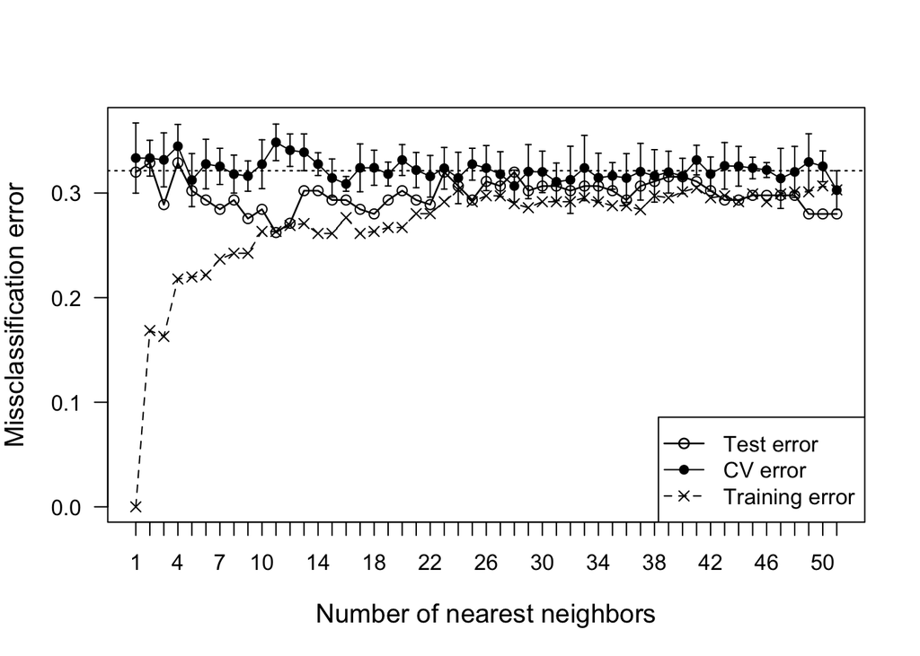

A combination of scaling the data and searching for the best cross-validated “k” is ideal.

### Challenge 1

# 2. Linear regression

- Ordinary least squares regression (OLS) can be used when the target Y variable is continuous.
- Remember that under the hood, `lm` and `glm` are one hot encoding factors to indicators. Write it out again for good practice:

```r
# View structure of Mroz.
str(Mroz)
```

```
## 'data.frame':    753 obs. of  8 variables:
##  $ lfp : Factor w/ 2 levels "no","yes": 2 2 2 2 2 2 2 2 2 2 ...
##  $ k5  : int  1 0 1 0 1 0 0 0 0 0 ...
##  $ k618: int  0 2 3 3 2 0 2 0 2 2 ...
##  $ age : int  32 30 35 34 31 54 37 54 48 39 ...
##  $ wc  : Factor w/ 2 levels "no","yes": 1 1 1 1 2 1 2 1 1 1 ...
##  $ hc  : Factor w/ 2 levels "no","yes": 1 1 1 1 1 1 1 1 1 1 ...
##  $ lwg : num  1.2102 0.3285 1.5141 0.0921 1.5243 ...
##  $ inc : num  10.9 19.5 12 6.8 20.1 ...
```

```r
# Define our continuous Y response variable, "lwg". Call it "Y2".
Y2 <- Mroz$lwg

# Expand our predictor X variables out into indicators.
data2 <- data.frame(model.matrix( ~ ., subset(Mroz, select = -lwg)))
names(data2)
```

```
## [1] "X.Intercept." "lfpyes"       "k5"           "k618"
## [5] "age"          "wcyes"        "hcyes"        "inc"
```

```r
# Remove intercept.
data2 <- data2[, -1]

# View structure of "data2".
str(data2)
```

```
## 'data.frame':    753 obs. of  7 variables:
##  $ lfpyes: num  1 1 1 1 1 1 1 1 1 1 ...
##  $ k5    : num  1 0 1 0 1 0 0 0 0 0 ...
##  $ k618  : num  0 2 3 3 2 0 2 0 2 2 ...
##  $ age   : num  32 30 35 34 31 54 37 54 48 39 ...
##  $ wcyes : num  0 0 0 0 1 0 1 0 0 0 ...
##  $ hcyes : num  0 0 0 0 0 0 0 0 0 0 ...
##  $ inc   : num  10.9 19.5 12 6.8 20.1 ...
```

- Fit a model that predicts the `Y` variable log wage gap (`lwg`) using the other variables as predictors.
- Mean squared error (MSE) will be our performance metric. MSE measures the difference between observed and expected values, with smaller values tending to reflect greater predictive accuracy.

```r
# Fit the regression model.
data2_lm <- lm(Y2 ~ ., data = data2)

# View the regression results.
summary(data2_lm)
```

```
##
## Call:
## lm(formula = Y2 ~ ., data = data2)
##
## Residuals:
##      Min       1Q   Median       3Q      Max
## -3.13347 -0.21039  0.02812  0.28386  2.22259
##
## Coefficients:
##               Estimate Std. Error t value Pr(>|t|)
## (Intercept)  0.8945523  0.1571922   5.691 1.82e-08 ***
## lfpyes       0.1768203  0.0434941   4.065 5.31e-05 ***
## k5          -0.0146796  0.0449973  -0.326   0.7443
## k618        -0.0413748  0.0166974  -2.478   0.0134 *
## age         -0.0001925  0.0030970  -0.062   0.9505
## wcyes        0.3419130  0.0540417   6.327 4.32e-10 ***
## hcyes        0.0146822  0.0510543   0.288   0.7737
## inc          0.0033639  0.0019046   1.766   0.0778 .
## ---
## Signif. codes:  0 '***' 0.001 '**' 0.01 '*' 0.05 '.' 0.1 ' ' 1
##
## Residual standard error: 0.5509 on 745 degrees of freedom
## Multiple R-squared:  0.129,  Adjusted R-squared:  0.1208
## F-statistic: 15.76 on 7 and 745 DF,  p-value: < 2.2e-16
```

```r
# Predict the outcome back onto the training data.
data2_predicted <- predict(data2_lm, data2)

# Calculate mean-squared error.
MSE <- mean((Y2 - data2_predicted)^2)

MSE
```

```
## [1] 0.3002928
```

See the [yhat blog for Fitting & Interpreting Linear Models in R](http://blog.yhat.com/posts/r-lm-summary.html) to learn more about `lm` output.

### Challenge 2

1. What happens to MSE when you try to predict “age” and “lfp”?
2. Set up a regression model that predicts one of the numeric variables from the “iris” dataset.

# 3. Decision trees

- Decision trees are recursive partitioning methods that divides the predictor spaces into simpler regions and can be visualized in a tree-like structure. Decesion trees attempt to classify data by dividing it into subsets according to a `Y` output variable and based on some predictors.
- Let’s see how a tree-based method classifies women’s participation in the workforce.

Note that we do not have to use `model.matrix` for our decision tree algorithm here:

```r
library(rpart)
# Choose method="anova" for a regression tree
# Instead of gini coefficient, select "information" inside the "parms" parameter
dt <- rpart(Mroz$lfp ~ ., data = subset(Mroz, select = -lfp),
            method = "class",
            parms = list(split = 'information'))

# Here is the text-based display of the decision tree. Yikes!
print(dt)
```

```
## n= 753
##
## node), split, n, loss, yval, (yprob)
##       * denotes terminal node
##
##  1) root 753 325 yes (0.43160691 0.56839309)
##    2) lwg< 1.331729 538 239 no (0.55576208 0.44423792)
##      4) lwg>=0.2044099 502 206 no (0.58964143 0.41035857)
##        8) inc>=14.442 327 112 no (0.65749235 0.34250765)
##         16) lwg>=0.6567131 286  86 no (0.69930070 0.30069930) *
##         17) lwg< 0.6567131 41  15 yes (0.36585366 0.63414634) *
##        9) inc< 14.442 175  81 yes (0.46285714 0.53714286)
##         18) k5>=0.5 37  11 no (0.70270270 0.29729730) *
##         19) k5< 0.5 138  55 yes (0.39855072 0.60144928)
##           38) age>=46.5 54  21 no (0.61111111 0.38888889)
##             76) inc>=6.511001 45  13 no (0.71111111 0.28888889) *
##             77) inc< 6.511001 9   1 yes (0.11111111 0.88888889) *
##           39) age< 46.5 84  22 yes (0.26190476 0.73809524) *
##      5) lwg< 0.2044099 36   3 yes (0.08333333 0.91666667) *
##    3) lwg>=1.331729 215  26 yes (0.12093023 0.87906977) *
```

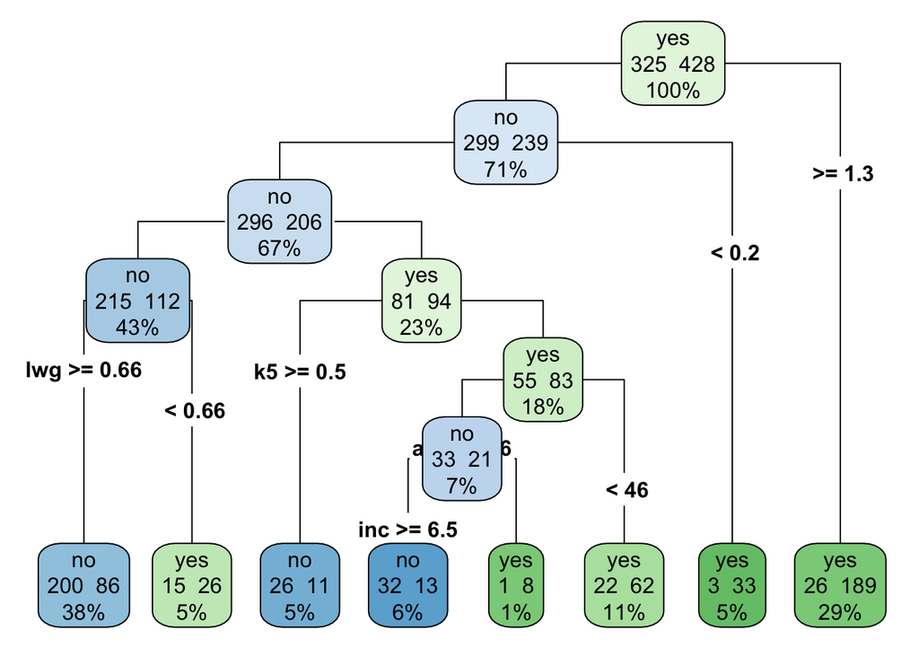

```r
# The plot is much easier to interpret.
library(rpart.plot)
rpart.plot(dt, cex = 1, type = 4, extra = 101)
```

```r
           # shadow.col = "lightgray",

# Variable importance is also informative:
dt$variable.importance
```

```
##       lwg       inc       age        wc        k5      k618
## 94.851147 15.385398  9.149330  7.984568  5.506937  3.214424
```

In decision trees the main hyperparameter (configuration setting) is the *complexity parameter* (CP). A high CP results in a simple decision tree with few splits, whereas a low CP results in a larger decision tree with many splits. So, the name is a little counterintuitive.

rpart uses cross-validation internally to estimate the accuracy at various complexity parameter (CP) settings. We can review those to see what setting seems best.

```r
# Print the results for various CP settings.
# Here we want the setting with the lowest "xerror".
printcp(dt)
```

```
##
## Classification tree:
## rpart(formula = Mroz$lfp ~ ., data = subset(Mroz, select = -lfp),
##     method = "class", parms = list(split = "information"))
##
## Variables actually used in tree construction:
## [1] age inc k5  lwg
##
## Root node error: 325/753 = 0.43161
##
## n= 753
##
##         CP nsplit rel error  xerror     xstd
## 1 0.184615      0   1.00000 1.00000 0.041820
## 2 0.092308      1   0.81538 0.82154 0.040392
## 3 0.043077      2   0.72308 0.76923 0.039762
## 4 0.036923      4   0.63692 0.75692 0.039600
## 5 0.033846      5   0.60000 0.73231 0.039256
## 6 0.021538      6   0.56615 0.65231 0.037974
## 7 0.010000      7   0.54462 0.60000 0.036987
```

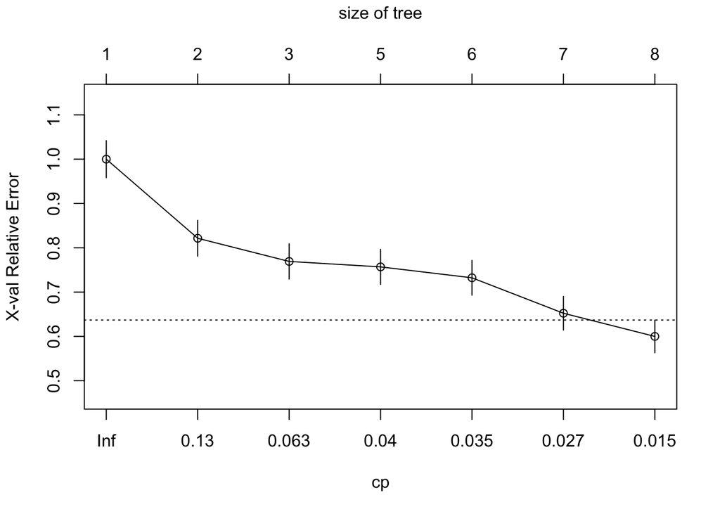

```r
# Plot the performance estimates for different CP settings.
# We see that a larger tree (lower CP) seems more accurate.
plotcp(dt)
```

```r
# We can "prune" a tree to a higher CP setting if we want.
# Note: due to rounding we make the cp value slightly higher than
# was shown in the table.
tree_pruned <- prune(dt, cp = 0.033847)

# Print detailed results, variable importance, and summary of splits.
summary(tree_pruned)
```

```
## Call:
## rpart(formula = Mroz$lfp ~ ., data = subset(Mroz, select = -lfp),
##     method = "class", parms = list(split = "information"))
##   n= 753
##
##           CP nsplit rel error    xerror       xstd
## 1 0.18461538      0 1.0000000 1.0000000 0.04181987
## 2 0.09230769      1 0.8153846 0.8215385 0.04039177
## 3 0.04307692      2 0.7230769 0.7692308 0.03976245
## 4 0.03692308      4 0.6369231 0.7569231 0.03959959
## 5 0.03384700      5 0.6000000 0.7323077 0.03925647
##
## Variable importance
##  lwg  inc  age   wc   k5 k618
##   71    8    8    7    5    3
##
## Node number 1: 753 observations,    complexity param=0.1846154
##   predicted class=yes  expected loss=0.4316069  P(node) =1
##     class counts:   325   428
##    probabilities: 0.432 0.568
##   left son=2 (538 obs) right son=3 (215 obs)
##   Primary splits:
##       lwg < 1.331729  to the left,  improve=66.026240, (0 missing)
##       k5  < 0.5       to the right, improve=16.001270, (0 missing)
##       wc  splits as  LR, improve= 7.537961, (0 missing)
##       inc < 21.3945   to the right, improve= 7.272398, (0 missing)
##       age < 47.5      to the right, improve= 4.765255, (0 missing)
##   Surrogate splits:
##       wc  splits as  LR, agree=0.749, adj=0.121, (0 split)
##       inc < 51.25     to the left,  agree=0.716, adj=0.005, (0 split)
##
## Node number 2: 538 observations,    complexity param=0.09230769
##   predicted class=no   expected loss=0.4442379  P(node) =0.7144754
##     class counts:   299   239
##    probabilities: 0.556 0.444
##   left son=4 (502 obs) right son=5 (36 obs)
##   Primary splits:
##       lwg < 0.2044098 to the right, improve=19.386020, (0 missing)
##       inc < 14.7495   to the right, improve= 8.293106, (0 missing)
##       k5  < 0.5       to the right, improve= 8.111923, (0 missing)
```

[output cut: 62 more lines]

```
##       hc  splits as  LR, improve=0.9670948, (0 missing)
##   Surrogate splits:
##       k618 < 0.5       to the left,  agree=0.754, adj=0.370, (0 split)
##       lwg  < 0.4188141 to the left,  agree=0.645, adj=0.093, (0 split)
##       inc  < 14.2985   to the right, agree=0.623, adj=0.037, (0 split)
##
## Node number 38: 54 observations
##   predicted class=no   expected loss=0.3888889  P(node) =0.07171315
##     class counts:    33    21
##    probabilities: 0.611 0.389
##
## Node number 39: 84 observations
##   predicted class=yes  expected loss=0.2619048  P(node) =0.1115538
##     class counts:    22    62
##    probabilities: 0.262 0.738
```

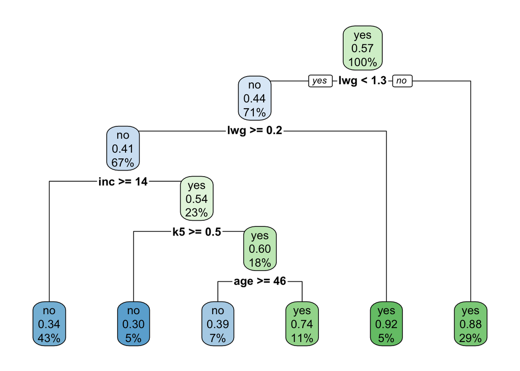

```r
rpart.plot(tree_pruned)
```

```r
# Also see the "control" argument inside the rpart function:
?rpart
```

Here, each node shows the cutoff for each of the predictors and how it contributed to the split. View a helpful decision tree tutorial at [GormAnalysis](https://gormanalysis.com/decision-trees-in-r-using-rpart/).

### Challenge 3

1. Make a decision tree that tries to classify something other than “lfp”.
2. What are the “minsplit” and “cp” hyperparameters within the “control” parameter? How might you go about figuring out what these are?  
   HINT: the syntax might look like this: `dt2_control <- rpart.control(minsplit = 20, cp = 0.001)`

# 4. Random forests

Random forest is an algorithm that seeks to improve on the performance of a single decision tree by taking the average of many trees. Thus, a random forest is an **ensemble** method, or model averaging approach. The algorithm was invented by Berkeley’s own Leo Breiman in 2001, who was also a co-creator of decision trees (see 1984 CART book).

Random forests are an extension of **bagging**, in which multiple samples of the original data are drawn with replacement (aka “bootstrap samples”), an algorithm is fit separately to each sample, then the average of those estimates is used for prediction. While bagging can be used any algorithm, RF uses decision trees as its base learner. Random Forests add another level of randomness by also randomly sampling the features (or covariates) at each split in each decision tree. This makes the decision trees use different covariates and therefore be more unique. As a result, the average of these trees tends to be more accurate overall.

```r
# View "Y" and "data"
table(Y)
```

```
## Y
##  no yes
## 325 428
```

```r
str(data)
```

```
## 'data.frame':    753 obs. of  7 variables:
##  $ k5   : num  1 0 1 0 1 0 0 0 0 0 ...
##  $ k618 : num  0 2 3 3 2 0 2 0 2 2 ...
##  $ age  : num  32 30 35 34 31 54 37 54 48 39 ...
##  $ wcyes: num  0 0 0 0 1 0 1 0 0 0 ...
##  $ hcyes: num  0 0 0 0 0 0 0 0 0 0 ...
##  $ lwg  : num  1.2102 0.3285 1.5141 0.0921 1.5243 ...
##  $ inc  : num  10.9 19.5 12 6.8 20.1 ...
```

```r
# split this data, similar to before
str(train_X)
```

```
## 'data.frame':    528 obs. of  7 variables:
##  $ k5   : num  1 0 1 0 0 0 0 1 0 0 ...
##  $ k618 : num  0 2 3 3 2 1 1 2 1 2 ...
##  $ age  : num  32 30 35 34 48 33 42 30 43 43 ...
##  $ wcyes: num  0 0 0 0 0 0 0 0 0 0 ...
##  $ hcyes: num  0 0 0 0 0 0 1 1 1 0 ...
##  $ lwg  : num  1.2102 0.3285 1.5141 0.0921 0.7543 ...
##  $ inc  : num  10.9 19.5 12 6.8 17.3 ...
```

```r
str(test_X)
```

```
## 'data.frame':    225 obs. of  7 variables:
##  $ k5   : num  1 0 0 0 0 0 0 0 0 0 ...
##  $ k618 : num  2 0 2 0 2 2 3 0 0 3 ...
##  $ age  : num  31 54 37 54 39 43 35 42 46 30 ...
##  $ wcyes: num  1 0 1 0 0 0 0 0 0 0 ...
##  $ hcyes: num  0 0 0 0 0 0 0 0 1 0 ...
##  $ lwg  : num  1.52 1.56 2.12 2.06 1.54 ...
##  $ inc  : num  20.1 9.86 9.15 10.9 12.93 ...
```

Now, let’s fit a model that tries to predict the number of women who participated in the labor force in 1975 again using the other variables as our X predictors:

```r
library(randomForest)
set.seed(1)
rf1 <- randomForest(train_label ~ .,
                    data = train_X,
                    # Number of trees
                    ntree = 500,
                    # Number of variables randomly sampled as candidates at each split.
                    mtry = 2,
                    # We want the importance of predictors to be assessed.
                    importance = TRUE)

rf1
```

```
##
## Call:
##  randomForest(formula = train_label ~ ., data = train_X, ntree = 500,      mtry = 2, importance = TRUE)
##                Type of random forest: classification
##                      Number of trees: 500
## No. of variables tried at each split: 2
##
##         OOB estimate of  error rate: 22.73%
## Confusion matrix:
##      no yes class.error
## no  171  57        0.25
## yes  63 237        0.21
```

The “OOB estimate of error rate” shows us how accurate our model is. $accuracy = 1 - error rate$. OOB stands for “out of bag” - and bag is short for “bootstrap aggregation”. So OOB estimates performance by comparing the predicted outcome value to the actual value across all trees using only the observations that were not part of the training data for that tree.

We can examine the relative variable importance in table and graph form. Random Forest estimates variable importance by separately examining each variable and estimating how much the model’s accuracy drops when that variable’s values are randomly shuffled (permuted). The shuffling temporarily removes any relationship between that covariate’s value and the outcome. If a variable is important then the model’s accuracy will suffer a large drop when it is randomly shuffled. But if the model’s accuracy doesn’t change it means the variable is not important to the model - e.g. maybe it was never even chosen as a split in any of the decision trees.

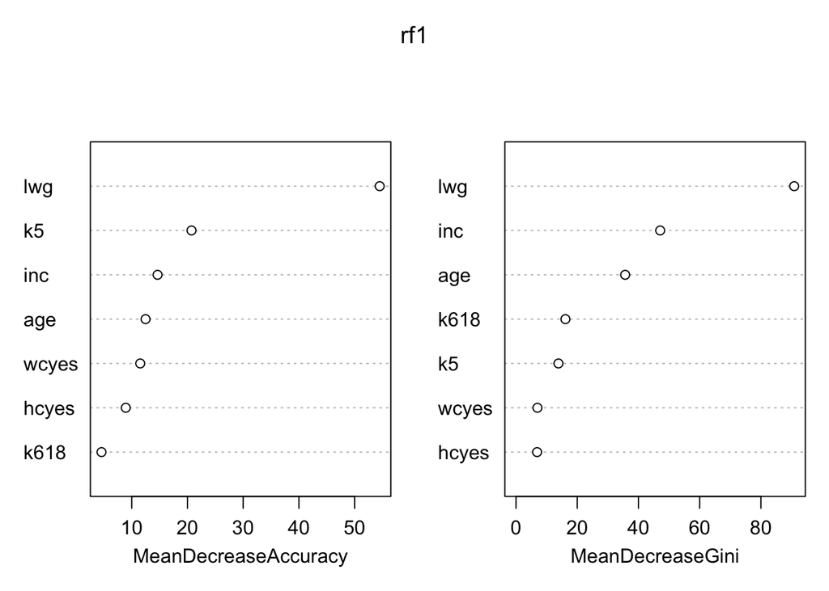

```r
# As the function name suggests, this creates a variable importance plot.
varImpPlot(rf1)
```

```r
# Raw data.
rf1$importance
```

```
##                no          yes MeanDecreaseAccuracy MeanDecreaseGini
## k5    0.042240861  0.008732059          0.023060604        13.868307
## k618  0.004845054  0.005447253          0.005138257        16.141638
## age   0.047477888 -0.003301003          0.018504542        35.665424
## wcyes 0.041394598 -0.010810779          0.011719443         7.000819
## hcyes 0.022873666 -0.001118901          0.009220482         6.894551
## lwg   0.155734810  0.073468666          0.108581082        90.870498
## inc   0.025682131  0.019712483          0.022086118        47.096675
```

You can read up on the [gini coefficient](https://en.wikipedia.org/wiki/Gini_coefficient) if interested. It’s basically a measure of diversity or dispersion - a higher gini means the model is classifying better. The gini version does not randomly shuffle the variable cells.

Now, the goal is to see how the model performs on the test dataset:

```r
rf_pred <- predict(rf1, newdata = test_X)
table(rf_pred, test_label)
```

```
##        test_label
## rf_pred  no yes
##     no   66  28
##     yes  31 100
```

Check the accuracy of the test set:

```r
mean(rf_pred == test_label) # 0.7377778
```

```
## [1] 0.7377778
```

```r
# devtools::install_github("ck37/ck37r")
summary(ck37r::rf_count_terminal_nodes(rf1))
```

```
##    Min. 1st Qu.  Median    Mean 3rd Qu.    Max.
##   31.00   81.75   90.00   88.79   98.25  126.00
```

How did it do? Are the accuracies for the training and test sets similar?

### Challenge 4

1. Try a few other values of mtry - can you find one that has improved performance?
2. Maxnodes is another tuning parameter for randomForest - does changing it improve your performance?
3. Select another Y variable to predict and evaluate performance on the train_rf and test_rf. How is the fit of the model for this variable?

# 5. Boosting

“Boosting is a general method for improving the accuracy of any given learning algorithm” and evolved from AdaBoost and PAC learning (p. 1-2). Gradient boosted machines are ensembles decision tree methods of “weak” trees that are just slightly more accurate than random guessing. These are then “boosted” into “strong” learners. That is, the models don’t have to be accurate over the entire feature space.

The model first tries to predict each value in a dataset - the cases that can be predicted easily are *downweighted* so that the algorithm does not try as hard to predict them.

However, the cases that the model has difficulty predicting are *upweighted* so that the model tries more assertively to predict them. This continues for multiple “boosting iterations”, with a training-based performance measure produced at each iteration. This method can drive down generalization error (p. 5). (from [Freund Y, Schapire RE. 1999. A short introduction to boosting. Journal of Japanese Society for Artificial Intelligence 14:771-780](https://cseweb.ucsd.edu/~yfreund/papers/IntroToBoosting.pdf).

Remember, our data are still split from before:

```r
# view "Y" and "data"
table(Y)
```

```
## Y
##  no yes
## 325 428
```

```r
str(data)
```

```
## 'data.frame':    753 obs. of  7 variables:
##  $ k5   : num  1 0 1 0 1 0 0 0 0 0 ...
##  $ k618 : num  0 2 3 3 2 0 2 0 2 2 ...
##  $ age  : num  32 30 35 34 31 54 37 54 48 39 ...
##  $ wcyes: num  0 0 0 0 1 0 1 0 0 0 ...
##  $ hcyes: num  0 0 0 0 0 0 0 0 0 0 ...
##  $ lwg  : num  1.2102 0.3285 1.5141 0.0921 1.5243 ...
##  $ inc  : num  10.9 19.5 12 6.8 20.1 ...
```

```r
nrow(train_X) + nrow(test_X) == nrow(data) # sanity check
```

```
## [1] TRUE
```

Rather than testing only a single model at a time, it is useful to compare tuning parameters within that single model. Bootstrap is often a default, but we want cross-validation. We also want to specify different tuning parameters.

Let us first create two objects - `control` and `grid`. `control` will allow us to tune the cross-validated performance metric, while `grid` lets us evaluate the model with different characteristics:

```r
# Choose 10-fold repeated measure cross-validation as our performance metric
# (instead of the default "bootstrap").
control <- trainControl(method = "repeatedcv",
    repeats = 2,
    # Calculate class probabilities.
    classProbs = TRUE,
    # Indicate that our response varaible is binary.
    summaryFunction = twoClassSummary)

grid <- expand.grid(
  # Number of trees to fit, aka boosting iterations.
  n.trees = seq(500, 1500, by = 500),
  # Depth of the decision tree.
    interaction.depth = c(1, 3, 5),
  # Learning rate: lower means the ensemble will adapt more slowly.
    shrinkage = c(0.001, 0.01, 0.1),
  # Stop splitting a tree if we only have this many obs in a tree node.
    n.minobsinnode = 10)
grid
```

```
##    n.trees interaction.depth shrinkage n.minobsinnode
## 1      500                 1     0.001             10
## 2     1000                 1     0.001             10
## 3     1500                 1     0.001             10
## 4      500                 3     0.001             10
## 5     1000                 3     0.001             10
## 6     1500                 3     0.001             10
## 7      500                 5     0.001             10
## 8     1000                 5     0.001             10
## 9     1500                 5     0.001             10
## 10     500                 1     0.010             10
## 11    1000                 1     0.010             10
## 12    1500                 1     0.010             10
## 13     500                 3     0.010             10
## 14    1000                 3     0.010             10
## 15    1500                 3     0.010             10
## 16     500                 5     0.010             10
## 17    1000                 5     0.010             10
## 18    1500                 5     0.010             10
## 19     500                 1     0.100             10
## 20    1000                 1     0.100             10
## 21    1500                 1     0.100             10
## 22     500                 3     0.100             10
## 23    1000                 3     0.100             10
## 24    1500                 3     0.100             10
## 25     500                 5     0.100             10
## 26    1000                 5     0.100             10
## 27    1500                 5     0.100             10
```

Fit the model. Note that we are now using the area under the ROC curve as our performance metric. This can be graphed for quick visualization:

```r
library(caret)
library(pROC)
set.seed(1)
label_numeric = as.numeric(train_label == "yes")
table(label_numeric, train_label)
```

```
##              train_label
## label_numeric  no yes
##             0 228   0
##             1   0 300
```

```r
# cbind: caret expects the Y response and X predictors to be part of the same dataframe
gbm1 <- train(train_label ~ ., data = cbind(train_label, train_X),
    method = "gbm",
    # Use AUC as our performance metric, which caret incorrectly calls "ROC".
    metric = "ROC",
    trControl = control,
    tuneGrid = grid,
    # Keep output more concise.
    verbose = T)
# See how long this algorithm took to complete.
gbm1$times
```

```
## $everything
##    user  system elapsed
##  56.240   0.085  56.359
##
## $final
##    user  system elapsed
##   0.497   0.001   0.498
##
## $prediction
## [1] NA NA NA
```

```r
# Review model summary table.
gbm1
```

```
## Stochastic Gradient Boosting
##
## 528 samples
##   7 predictor
##   2 classes: 'no', 'yes'
##
## No pre-processing
## Resampling: Cross-Validated (10 fold, repeated 2 times)
## Summary of sample sizes: 475, 475, 475, 475, 475, 476, ...
## Resampling results across tuning parameters:
##
##   shrinkage  interaction.depth  n.trees  ROC        Sens       Spec
##   0.001      1                   500     0.7686594  0.0000000  1.0000000
##   0.001      1                  1000     0.7960968  0.6426877  0.7416667
##   0.001      1                  1500     0.8006555  0.7542490  0.6783333
##   0.001      3                   500     0.7977701  0.5614625  0.8266667
##   0.001      3                  1000     0.8044862  0.6796443  0.7750000
##   0.001      3                  1500     0.8087088  0.7060277  0.7666667
##   0.001      5                   500     0.8053722  0.5811265  0.8233333
##   0.001      5                  1000     0.8118149  0.6731225  0.7800000
##   0.001      5                  1500     0.8172134  0.6971344  0.7700000
##   0.010      1                   500     0.8114328  0.7254941  0.7416667
##   0.010      1                  1000     0.8131719  0.7167984  0.7483333
##   0.010      1                  1500     0.8147694  0.7082016  0.7483333
##   0.010      3                   500     0.8236726  0.7187747  0.7700000
##   0.010      3                  1000     0.8306983  0.7145257  0.7833333
##   0.010      3                  1500     0.8312648  0.7166996  0.7783333
##   0.010      5                   500     0.8313801  0.7082016  0.7833333
##   0.010      5                  1000     0.8306950  0.7102767  0.7783333
##   0.010      5                  1500     0.8316337  0.7259881  0.7750000
##   0.100      1                   500     0.8120718  0.6883399  0.7616667
##   0.100      1                  1000     0.8077635  0.6949605  0.7583333
##   0.100      1                  1500     0.8069631  0.6819170  0.7583333
##   0.100      3                   500     0.8184947  0.7016798  0.7866667
##   0.100      3                  1000     0.8150198  0.6863636  0.7883333
##   0.100      3                  1500     0.8162286  0.7039526  0.7783333
##   0.100      5                   500     0.8105830  0.6880435  0.7700000
##   0.100      5                  1000     0.8108136  0.6751976  0.7683333
##   0.100      5                  1500     0.8088768  0.6884387  0.7666667
##
## Tuning parameter 'n.minobsinnode' was held constant at a value of 10
## ROC was used to select the optimal model using the largest value.
## The final values used for the model were n.trees = 1500,
##  interaction.depth = 5, shrinkage = 0.01 and n.minobsinnode = 10.
```

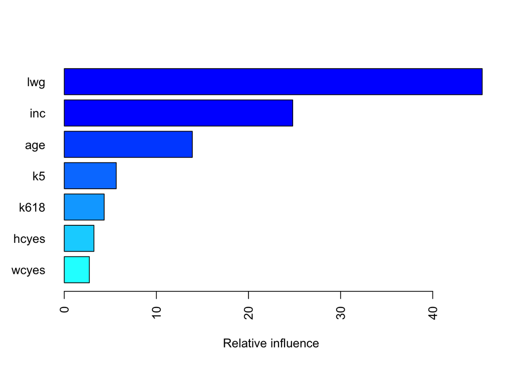

```
##         var   rel.inf
## lwg     lwg 45.377230
## inc     inc 24.802059
## age     age 13.901979
## k5       k5  5.643071
## k618   k618  4.329449
## hcyes hcyes  3.221593
## wcyes wcyes  2.724619
```

```r
# Plot variable importance.
summary(gbm1, las = 2)
```

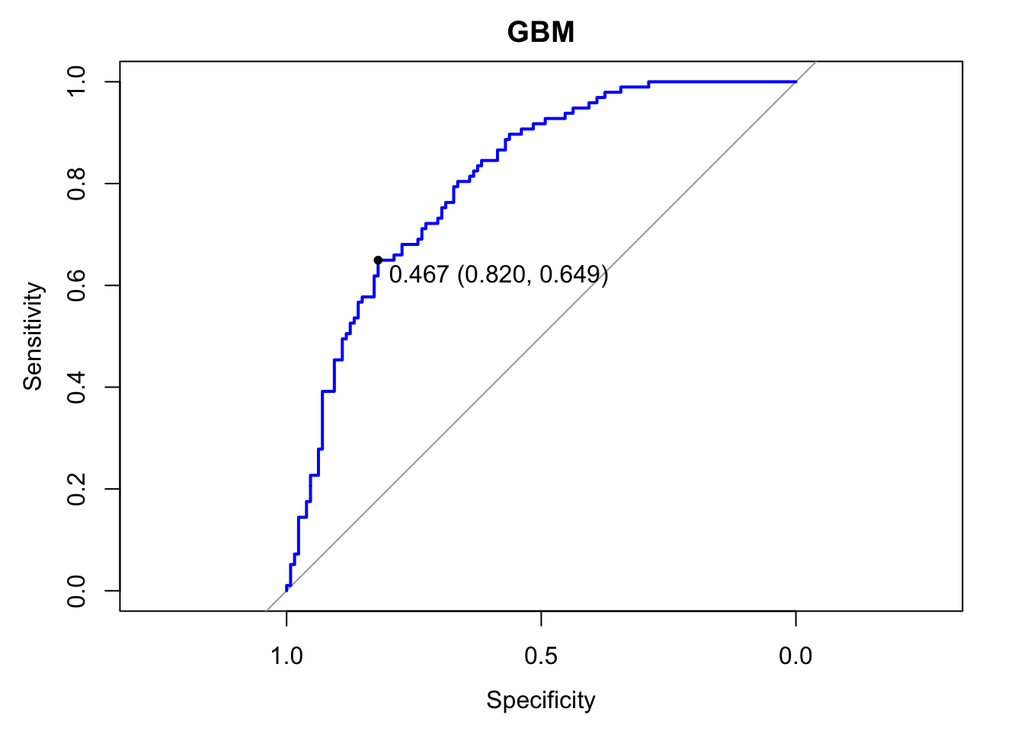

```r
# Generate predicted values.
gbm.pred <- predict(gbm1, test_X)

# Generate class probabilities.
gbm.prob <- predict(gbm1, test_X, type = "prob")

# Define ROC characteristics.
rocCurve <- roc(response = test_label,
    predictor = gbm.prob[, "yes"],
    levels = rev(levels(test_label)),
    auc=TRUE, ci=TRUE)

# Plot ROC.
plot(rocCurve, print.thres = "best", main = "GBM", col = "blue")
```

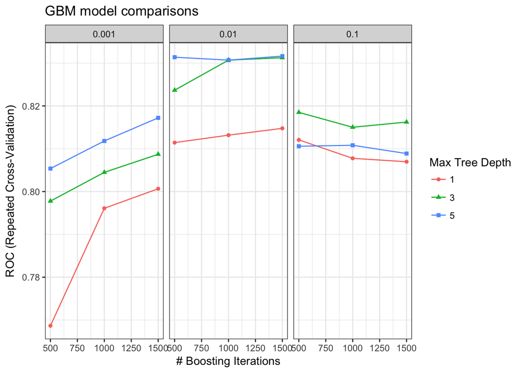

```r
# ggsave("gbm AUC.png")

# Plot the cross-validated AUC of the different configurations.
ggplot(gbm1) + theme_bw() + ggtitle("GBM model comparisons")
```

```r
# ggsave("gbm tuning comparison.png")
```

Also check out the [“xgboost” R package](https://cran.r-project.org/web/packages/xgboost/index.html) for extreme gradient boosting.

### Challenge 5

1. Using your Mroz dataset, fit a GBM model where “wc” is your Y variable. What happens to variable relative importance? What happens to AUC?

# 6. Ensemble methods

The [“SuperLearner” R package](https://cran.r-project.org/web/packages/SuperLearner/index.html) is a method that simplifies ensemble learning by allowing you to simultaneously evaluate the cross-validated performance of multiple algorithms and/or a single algorithm with differently tuned hyperparameters.

A “wrapper” is a short function that adapts an algorithm for the SuperLearner package. Check out the different algorithm wrappers offered by SuperLearner:

```r
library(SuperLearner)
listWrappers()
```

```
## All prediction algorithm wrappers in SuperLearner:
```

```
##  [1] "SL.bartMachine"      "SL.bayesglm"         "SL.biglasso"
##  [4] "SL.caret"            "SL.caret.rpart"      "SL.cforest"
##  [7] "SL.dbarts"           "SL.earth"            "SL.extraTrees"
## [10] "SL.gam"              "SL.gbm"              "SL.glm"
## [13] "SL.glm.interaction"  "SL.glmnet"           "SL.ipredbagg"
## [16] "SL.kernelKnn"        "SL.knn"              "SL.ksvm"
## [19] "SL.lda"              "SL.leekasso"         "SL.lm"
## [22] "SL.loess"            "SL.logreg"           "SL.mean"
## [25] "SL.nnet"             "SL.nnls"             "SL.polymars"
## [28] "SL.qda"              "SL.randomForest"     "SL.ranger"
## [31] "SL.ridge"            "SL.rpart"            "SL.rpartPrune"
## [34] "SL.speedglm"         "SL.speedlm"          "SL.step"
## [37] "SL.step.forward"     "SL.step.interaction" "SL.stepAIC"
## [40] "SL.svm"              "SL.template"         "SL.xgboost"
```

```
##
## All screening algorithm wrappers in SuperLearner:
```

```
## [1] "All"
## [1] "screen.corP"           "screen.corRank"        "screen.glmnet"
## [4] "screen.randomForest"   "screen.SIS"            "screen.template"
## [7] "screen.ttest"          "write.screen.template"
```

Instead of splitting the data like before, since we are using cross-validation we actually want to use the entire `Mroz` dataset:

```r
str(Mroz)
```

```
## 'data.frame':    753 obs. of  8 variables:
##  $ lfp : Factor w/ 2 levels "no","yes": 2 2 2 2 2 2 2 2 2 2 ...
##  $ k5  : int  1 0 1 0 1 0 0 0 0 0 ...
##  $ k618: int  0 2 3 3 2 0 2 0 2 2 ...
##  $ age : int  32 30 35 34 31 54 37 54 48 39 ...
##  $ wc  : Factor w/ 2 levels "no","yes": 1 1 1 1 2 1 2 1 1 1 ...
##  $ hc  : Factor w/ 2 levels "no","yes": 1 1 1 1 1 1 1 1 1 1 ...
##  $ lwg : num  1.2102 0.3285 1.5141 0.0921 1.5243 ...
##  $ inc : num  10.9 19.5 12 6.8 20.1 ...
```

```r
# convert our Y variable to numeric type
Mroz$lfp <- ifelse(Mroz$lfp == "yes", 1, 0)

# Now, tell SuperLearner which algorithms to urn. In the interest of time we are not including GBM, but "SL.gbm" is the wrapper.
SL_library <- c("SL.mean", "SL.knn", "SL.glm", "SL.rpart", "SL.randomForest")
```

Fit the ensemble:

```r
library(SuperLearner)
# This is a seed that is compatible with multicore parallel processing.
# See ?set.seed for more information.
set.seed(1, "L'Ecuyer-CMRG")

# This may take a minute to execute.
cv_sl <- CV.SuperLearner(Y = Mroz$lfp, X = data,
                         SL.library = SL_library,
                         family = binomial(),
                         # Fit only 5 folds for demo purposes only.
                         # For a real analysis we would do 20 folds.
                         cvControl = list(V = 5),
                         # Set to T to show details.
                         verbose = F)
summary(cv_sl)
```

```
##
## Call:
## CV.SuperLearner(Y = Mroz$lfp, X = data, family = binomial(), SL.library = SL_library,
##     verbose = F, cvControl = list(V = 5))
##
## Risk is based on: Mean Squared Error
##
## All risk estimates are based on V =  5
##
##            Algorithm     Ave        se     Min     Max
##        Super Learner 0.17299 0.0071637 0.15036 0.19576
##          Discrete SL 0.17327 0.0072964 0.15003 0.19643
##          SL.mean_All 0.24609 0.0024979 0.23910 0.25200
##           SL.knn_All 0.26464 0.0063521 0.25364 0.27673
##           SL.glm_All 0.21290 0.0063983 0.20385 0.23064
##         SL.rpart_All 0.20057 0.0094446 0.17752 0.22275
##  SL.randomForest_All 0.17327 0.0072964 0.15003 0.19643
```

Risk is a performance estimate - it’s the average loss, and loss is how far off the prediction was for an individual observation. The lower the risk, the fewer errors the model makes in its prediction. SuperLearner’s default loss metric is squared error $(y_{actual} - y_{predicted})^2$, so the risk is the mean-squared error (just like in ordinary least *squares* regression). View and plot results:

```r
summary(cv_sl)
```

```
##
## Call:
## CV.SuperLearner(Y = Mroz$lfp, X = data, family = binomial(), SL.library = SL_library,
##     verbose = F, cvControl = list(V = 5))
##
## Risk is based on: Mean Squared Error
##
## All risk estimates are based on V =  5
##
##            Algorithm     Ave        se     Min     Max
##        Super Learner 0.17299 0.0071637 0.15036 0.19576
##          Discrete SL 0.17327 0.0072964 0.15003 0.19643
##          SL.mean_All 0.24609 0.0024979 0.23910 0.25200
##           SL.knn_All 0.26464 0.0063521 0.25364 0.27673
##           SL.glm_All 0.21290 0.0063983 0.20385 0.23064
##         SL.rpart_All 0.20057 0.0094446 0.17752 0.22275
##  SL.randomForest_All 0.17327 0.0072964 0.15003 0.19643
```

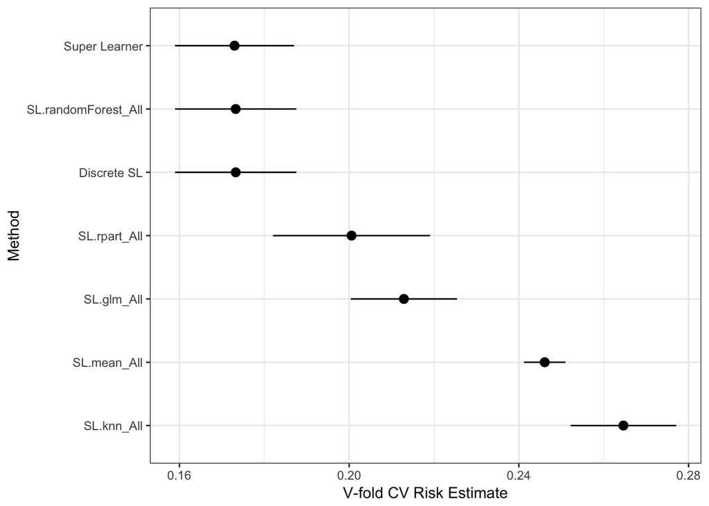

```r
plot(cv_sl) + theme_bw()
```

```r
# ggsave("SuperLearner.pdf")
```

“Discrete SL” is when the SuperLearner chooses the single algorithm with the lowest risk. “SuperLearner” is a weighted average of multiple algorithms, or an “ensemble”. In theory the weighted-average should have a little better performance, although they often tie. In this case we only have a few algorithms so the difference is minor.

### Challenge 6.

1. If you set the seed again and re-run `CV.SuperLearner` do you get exactly the same results?
2. Choose your favorite 2 algorithms and re-run the SuperLearner with just those algorithms in the library. Does the performance change?
3. What are the elements of the CV_SL object? Take a look at 1 or 2 of them. Hint: use the `names()` function to list the elements of an object, then `$` to access them (just like a dataframe).

A longer tutorial on SuperLearner is available here: https://github.com/ck37/superlearner-guide